# SureTypeSCR – R package for (single cell) SNP array data

Ivan Vogel, Lishan Cai

May 28, 2021

# 1 Introduction

SureTypeSCR is an R package for QC and rapid genotyping of single cell SNP array data. It encapsulates previously developed library SureTypeSC ([paper](https://academic.oup.com/bioinformatics/article/35/23/5055/5497252)). The core consists of a two layered machine learning method that assigns a quality score to each SNP in an array. On top of that, SureTypeSCR implements various QC strategies to examine the data. SureTypeSCR is extensively using packages from the tidyverse collection thereby allowing to apply modern data science approach to query the data.

This tutorial gives basic introduction to the data analysis with SureTypeSCR. The data used in this tutorial is publicly available ([paper](https://pubmed.ncbi.nlm.nih.gov/20100701/) and [data](https://www.ncbi.nlm.nih.gov/geo/query/acc.cgi?acc=GSE19247)) and subset of it (sperm data amplified by MDA) was transformed into an R data package for purpose of this demonstration.

# 2 Installation of the program and the data and initialization

Both, **SureTypeSCR** and **johnsonspermdata** can be installed from github repository using devtools. The dependencies should be installed automatically.

```r
library(devtools)

##install  SureTypeSCR  from  github
#devtools::install_github("Meiomap/SureTypeSCR",force=TRUE)

##install  data  package  with  sperm  data (compiled  from  GSE19247)
#devtools::install_github("Meiomap/johnsonspermdata")
```

When loaded for the first time, SureTypeSCR will create a python virtual environment and install all required python libraries via python package installer (pip).

```r
library(SureTypeSCR)
library(johnsonspermdata)
#library(tidyverse)
#library(magrittr)
#library(ggrepel)
# load  metadata  and  samplesheet  location
data(metadata ,samplesheet)
```

# 3 Data loading and feature extraction

```r
manifest=system.file("files/HumanCytoSNP-12v2_H.bpm",package="SureTypeSCR")
cluster=system.file("files/HumanCytoSNP-12v2_H.egt",package="SureTypeSCR")
df = scbasic(samplesheet=samplesheet , bpm=manifest , egt=cluster)
```

## 3.1 Filtering

After loading the basic dataframe **df** we filter out markers that do not contain genotypes (so called intensity-only SNPs) and view the structure of the data frame.

```r
#filtering  out  intensity -only  SNPs
df %<>% dplyr::filter(Chr!=0 & !str_detect(Name ,"cnv"))
head(df)
```

```
##        Name Chr  Position individual b_allele_freq gtype log_r_ratio
## 1 rs1000002   3 183635768  gsm477532     0.9859948    BB   -1.009453
## 2 rs1000002   3 183635768  gsm477533     0.8003091    AB   -4.800915
## 3 rs1000002   3 183635768  gsm477534     0.8919672    BB   -4.125801
## 4 rs1000002   3 183635768  gsm477535     0.3622532    AB   -4.449686
## 5 rs1000002   3 183635768  gsm477536     0.6464212    AB   -3.152554
## 6 rs1000002   3 183635768  gsm477537     0.2595262    AB   -3.872426
##         score           x x_raw          y y_raw
## 1 0.869653046 0.019764755  1031 0.40287372  8306
## 2 0.009361755 0.008056554   504 0.02349852   937
## 3 0.014443527 0.008048215   752 0.04152295  1591
## 4 0.022765663 0.024449598   498 0.01598536   512
## 5 0.165830925 0.039333437   729 0.06226622  1067
## 6 0.040316373 0.040040240   645 0.01812202   610
```

# 4 Call rates

Call rates can be calculated per group basis - here per individual (sample) and genotype and functions from tidyverse can be used to reshape the results for better readability.

```r
df %>%
  group_by(individual ,gtype) %>%
  callrate() %>%
  pivot_wider(values_from=Callrate,names_from=gtype)
```

```
## # A tibble: 23 x 5
## # Groups:   individual [23]
##    individual    AA    AB    BB    NC
##    <chr>      <dbl> <dbl> <dbl> <dbl>
##  1 gsm477532  0.223 0.134 0.228 0.415
##  2 gsm477533  0.235 0.100 0.251 0.415
##  3 gsm477534  0.218 0.141 0.227 0.415
##  4 gsm477535  0.184 0.227 0.174 0.415
##  5 gsm477536  0.175 0.224 0.187 0.415
##  6 gsm477537  0.220 0.170 0.196 0.415
##  7 gsm477538  0.209 0.187 0.190 0.415
##  8 gsm477539  0.167 0.211 0.207 0.415
##  9 gsm477540  0.161 0.214 0.210 0.415
## 10 gsm477541  0.181 0.204 0.200 0.415
## # ... with 13 more rows
```

# 5 Principal component analysis

Principal component analysis determines relationships between the individuals by reducing n-dimensional representation of SNP array data (n is equal to total number of SNPs that call in every sample) into few (here two) dimensions that maximize the variation (explain most of the variability). The user has an option whether to calculate the PCA per chromosome basis (parameter **by_chrom**), which can reveal potential aneuploidies or just to reveal relationship between samples across all SNPs in one PCA.

```
## [1] "PCA from  174231  features"
```

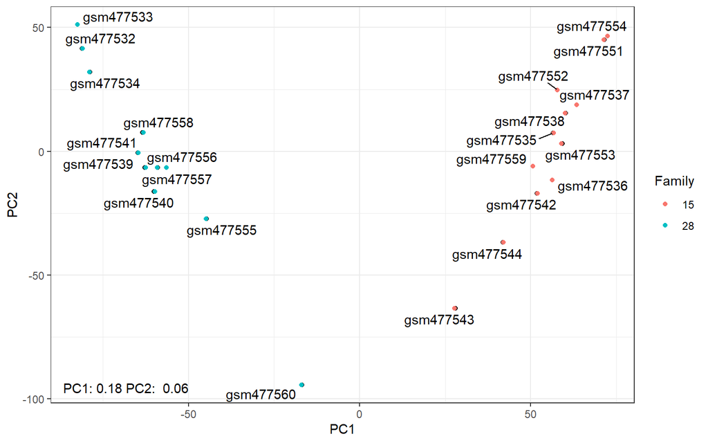

```r
df %>%
  plot_pca(features="gtype", metadata=metadata ,by_chrom=FALSE)
```

# 6 MA transformation

MA transformation displays intensities as logarithmic average (A) and logarithmic difference (M). Roughly speaking, M~0 corresponds to heterozygous genotypes, M<0 corresponds to homozygous B and M>0 corresponds to homozygous A. As explained in Vogel *et al.* (2019), MA transformation minimizes the intra-group variability and allows visualise the genotyping clusters (AA, BB and AB) across the whole dataset.

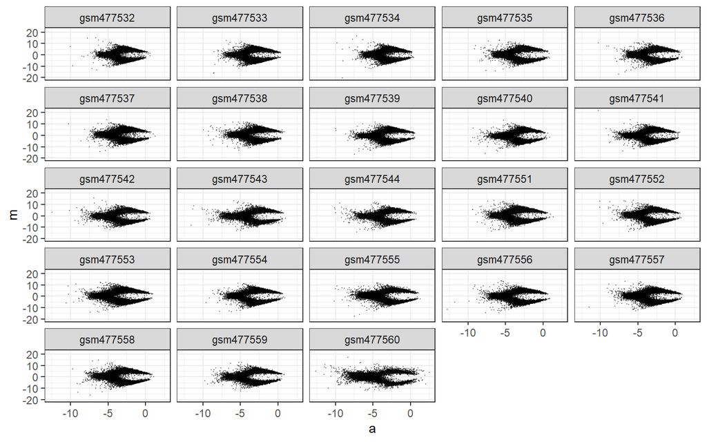

```r
df %>%
  calculate_ma() %>%
  plot_ma(n=0.1)
```

# 7 Single cell genotype classification

The classification of the single cell genotypes is performed via pretrained classifier (Random Forest) that is distributed within the package. A second layer of the algorithm (Gaussian Discriminant Analysis) is executed directly on the data and per sample basis.

```r
clf=system.file("files/rf.clf",package="SureTypeSCR")
df_model = df %>%
  calculate_ma() %>%
  group_by(individual) %>%
  nest() %>%
  mutate(model=map(data , function(df) suretype_model(df,individual , clf)))
```

```
## Processing sample gsm477532
## Processing sample gsm477533
## Processing sample gsm477534
## Processing sample gsm477535
## Processing sample gsm477536
## Processing sample gsm477537
## Processing sample gsm477538
## Processing sample gsm477539
## Processing sample gsm477540
## Processing sample gsm477541
## Processing sample gsm477542
## Processing sample gsm477543
## Processing sample gsm477544
## Processing sample gsm477551
## Processing sample gsm477552
## Processing sample gsm477553
## Processing sample gsm477554
## Processing sample gsm477555
## Processing sample gsm477556
## Processing sample gsm477557
## Processing sample gsm477558
## Processing sample gsm477559
## Processing sample gsm477560
```

```r
head(df_model)
```

```
## # A tibble: 6 x 3
## # Groups:   individual [6]
##   individual data                    model
##   <chr>      <list>                  <list>
## 1 gsm477532  <tibble [298,412 x 15]> <tibble [298,412 x 2]>
## 2 gsm477533  <tibble [298,412 x 15]> <tibble [298,412 x 2]>
## 3 gsm477534  <tibble [298,412 x 15]> <tibble [298,412 x 2]>
## 4 gsm477535  <tibble [298,412 x 15]> <tibble [298,412 x 2]>
## 5 gsm477536  <tibble [298,412 x 15]> <tibble [298,412 x 2]>
## 6 gsm477537  <tibble [298,412 x 15]> <tibble [298,412 x 2]>
```

If we visualise the MA plot again - this time for the filtered data to explore the effect of the RF-GDA algorithm, we can see that the algorithm has effectively filtered out the heterozygous genotypes (m ~ 0). The heterozygous genotypes are likely artefacts and products of erroneous whole genome amplification (WGA) as sperm cells are haploid and there were no aneuploidies reported on these samples (Johnson *et al.*, 2010).

```r
df_model_unnested = df_model %>%
  unnest(c(data ,model))
head(df_model_unnested)
```

```
## # A tibble: 6 x 18
## # Groups:   individual [1]
##   individual Name       Chr    Position b_allele_freq gtype log_r_ratio   score
##   <chr>      <chr>      <chr>     <dbl>         <dbl> <chr>       <dbl>   <dbl>
## 1 gsm477532  rs1000002  3     183635768       0.986   BB         -1.01  0.870
## 2 gsm477532  rs1000003  3      98342907       0.00834 AA         -0.367 0.932
## 3 gsm477532  rs10000030 4     103374154       0.335   AB         -2.87  0
## 4 gsm477532  rs10000037 4      38924330       0       AA          0.363 0.918
## 5 gsm477532  rs10000041 4     165621955     NaN       NC        NaN     0
## 6 gsm477532  rs1000007  2     237752054       0.821   BB         -3.27  0.00924
## # ... with 10 more variables: x <dbl>, x_raw <int>, y <dbl>, y_raw <int>,
## #   m <dbl>, a <dbl>, m_raw <dbl>, a_raw <dbl>, rfgda_score <dbl>,
## #   rf_score <dbl>
```

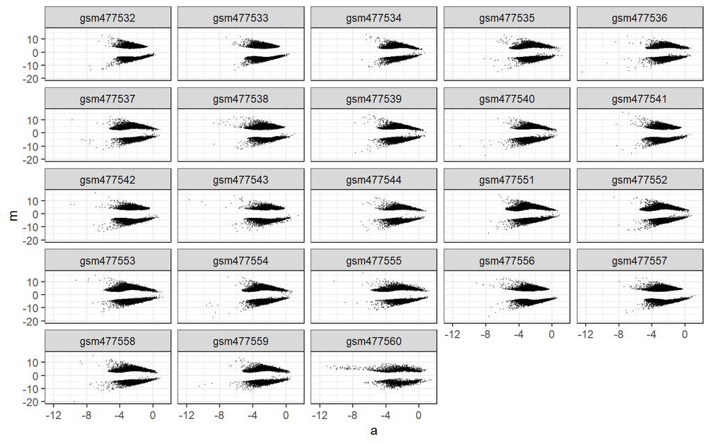

```r
df_model_unnested %>%
  set_threshold('rfgda_score',threshold =0.5) %>%
  plot_ma(n=0.1)
```

## 7.1 Conditional processing

An optional parameter of function **suretype_model(.)** is **.sclist** that controls samples that will be processed using RF-GDA algorithm (by default, all samples in the dataset are analysed). The following example demonstrates use case when we only want to analyze subset of samples as single cells - this is particularly useful in case there are also bulk DNA samples (i.e. parental genotypes) in the dataset and we wish to filter those samples out. First we list all sample names in the dataset:

```r
df %>%
  select(individual) %>%
  distinct()
```

```
##    individual
## 1   gsm477532
## 2   gsm477533
## 3   gsm477534
## 4   gsm477535
## 5   gsm477536
## 6   gsm477537
## 7   gsm477538
## 8   gsm477539
## 9   gsm477540
## 10  gsm477541
## 11  gsm477542
## 12  gsm477543
## 13  gsm477544
## 14  gsm477551
## 15  gsm477552
## 16  gsm477553
## 17  gsm477554
## 18  gsm477555
## 19  gsm477556
## 20  gsm477557
## 21  gsm477558
## 22  gsm477559
## 23  gsm477560
```

And now we only choose sample **gsm477532** and **gsm477533** for classification.

```r
sample_subset=list('gsm477532','gsm477533')

df_model = df %>%
  calculate_ma() %>%
  group_by(individual) %>%
  nest() %>%
  mutate(model=map(data , function(df) suretype_model(df,individual,clf,.sclist=sample_subset)))
```

```
## Processing sample gsm477532
## Processing sample gsm477533
```

Mean and standard deviation of the score per sample clearly shows that only the selected samples were process while all the other samples were assigned score 1 for all genotypes.

```r
df_model %>%
  unnest(c(data ,model)) %>%
  group_by(individual)  %>%
  summarize(mean = mean(rfgda_score,na.rm=TRUE),
    sd = sd(rfgda_score,na.rm=TRUE))
```

```
## # A tibble: 23 x 3
##    individual  mean    sd
##    <chr>      <dbl> <dbl>
##  1 gsm477532  0.491 0.385
##  2 gsm477533  0.573 0.369
##  3 gsm477534  1     0
##  4 gsm477535  1     0
##  5 gsm477536  1     0
##  6 gsm477537  1     0
##  7 gsm477538  1     0
##  8 gsm477539  1     0
##  9 gsm477540  1     0
## 10 gsm477541  1     0
## # ... with 13 more rows
```

# 8 Further information